# Practical machine Learning - Writeup

Dylan

2024-04-22

## Background and the Data

Six participants were asked to perform one set of 10 reptitions of the Unilateral Bumbbell Biceps Curl in 5 different fashions

- A: exactly to specification

- B: throwing elbows to the front

- C: lifting dumbbell only half way

- D: lowering the dumbbell only halfway

Participants wore accelerometer sensors on four locations: arm, forearm, waist, and dumbbell. Sensor readings were recorded while the participants performed the activities at different specification, under supervision of experienced trainer, and labeled accordingly.

### Selecting Features

Model fitting will be done on portion of the `pml-training.csv` data. Quick look at the data set shows that some metadata like row number, participant name, time stamps, etc. are included in column 1~7. Since they are not sensor readings, we will remove them from model fitting. Some columns also have class of `character`, which we will convert to numeric values.

```r
library(caret)
library(dplyr)
```

```r
library(ggplot2)
```

```r
pml_training <- read.csv(file.path(getwd(), "data", "pml-training.csv"))

dim(pml_training)
```

```
## [1] 19622   160
```

```r
names(pml_training)[1:8]
```

```
## [1] "X"                    "user_name"            "raw_timestamp_part_1"
## [4] "raw_timestamp_part_2" "cvtd_timestamp"       "new_window"
## [7] "num_window"           "roll_belt"
```

Removing column 1~7 and changing column classes

```r
# Transform training data
pml_training <- pml_training %>%
  select(-c(1:7)) %>%
  mutate(
    classe = as.factor(classe),
    across(roll_belt:magnet_forearm_z, ~ as.numeric(.x))
    )
```

Further exploration shows that there are quite a lot of missing values in the data set.

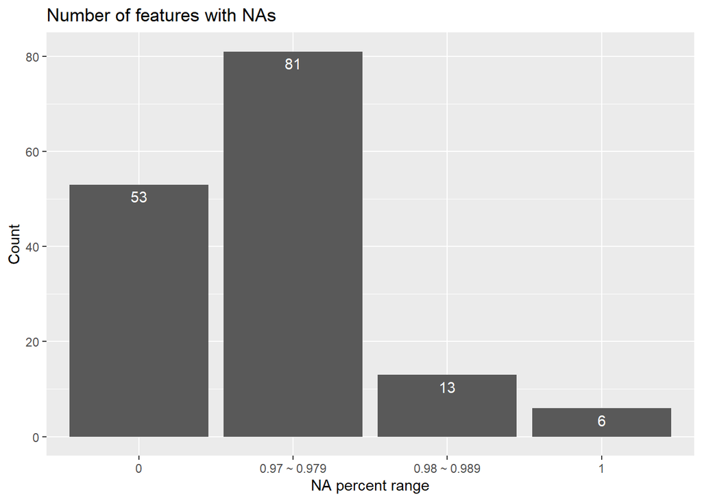

```r
col_na <- pml_training %>%
  summarize(across(everything(), ~ sum(is.na(.))))

na_tab <- data.frame(
  col_names = names(col_na),
  na_count = as.numeric(col_na[1,])
)

na_tab <- na_tab %>%
  mutate(
    na_perc = na_count/nrow(pml_training)
  ) %>%
  arrange(desc(na_perc))

na_summary <- na_tab %>% group_by(na_perc) %>%
  summarize(feature_count = n()) %>%
  mutate(na_perc_bracket = case_when(
    na_perc >= 0.97 & na_perc < 0.98 ~ "0.97 ~ 0.979",
    na_perc >= 0.98 & na_perc < 0.99 ~ "0.98 ~ 0.989",
    na_perc >= 0.99 & na_perc < 0.99 ~ "0.99 ~ 0.999",
    na_perc == 1 ~ "1",
    na_perc == 0 ~ "0"
  )) %>%
  group_by(na_perc_bracket) %>%
  summarize(
    feature_count = sum(feature_count)
  ) %>%
  arrange(desc(na_perc_bracket))

ggplot(na_summary, aes(na_perc_bracket, feature_count)) +
  geom_col() +
  geom_text(aes(label = feature_count), color = "white", nudge_y = -2.5) +
  labs(
    title = "Number of features with NAs",
    x = "NA percent range",
    y = "Count"
  )
```

100 of the accelerometer related features contain more than 97% NA. Only 53 features have 0% NA.

We will use only the features without missing values for modeling.

```r
# Filter for features with 0 NA
select_col <- na_tab %>%
  filter(na_perc == 0)

# extract col names
name_vec <- select_col$col_names

# extract select columns
pml_training_select <- pml_training %>%
  select(one_of(name_vec))
```

## The Setup

Now that we have chosen the features to fit the model, we further partition the data into testing and training set.

```r
set.seed(6525485)
# index
inTrain <- createDataPartition(y = pml_training_select$classe,                               p=0.75, list=FALSE)
# filter
training <- pml_training_select[inTrain,]
testing <- pml_training_select[-inTrain,]
dim(training); dim(testing)
```

```
## [1] 14718    53
```

```
## [1] 4904   53
```

## Model Fitting

We will use random forest to fit the model through the `caret` package. Random forest has the advantages of providing high accuracy, flexibility over non-linear data, while staying fairly robust to overfitting.

### Training Specification

First, we make some specifications to training control.

We will expand tuning grid for `mtry` parameter beyond the default. Next, we specify the cross-validation control in the `trainControl()` function. We choose k = 5 fold for cross-validation because anything bigger than that will really inflate the computation time.

```r
myTuneGrid <- data.frame(
  .mtry = c(5, 15, 25, 35, 45, 52)
)

myControl <- trainControl(
  method = "cv",
  number = 5,
  verboseIter = FALSE
)
```

### Fitting the Random Forest Model

Now we are ready to fit the model using the specifications we have saved.

```r
# Takes quite a while to run...
fit_rf_2 <- train(
  classe ~.,
  data = training,
  method = "rf",
  tuneGrid = myTuneGrid,
  trControl = myControl
)
```

Let’s take a look at the summary information on the model:

```r
fit_rf_2
```

```
## Random Forest
##
## 14718 samples
##    52 predictor
##     5 classes: 'A', 'B', 'C', 'D', 'E'
##
## No pre-processing
## Resampling: Cross-Validated (5 fold)
## Summary of sample sizes: 11775, 11774, 11775, 11773, 11775
## Resampling results across tuning parameters:
##
##   mtry  Accuracy   Kappa
##    5    0.9934775  0.9917489
##   15    0.9929340  0.9910614
##   25    0.9917789  0.9896006
##   35    0.9894689  0.9866774
##   45    0.9866153  0.9830672
##   52    0.9841694  0.9799729
##
## Accuracy was used to select the optimal model using the largest value.
## The final value used for the model was mtry = 5.
```

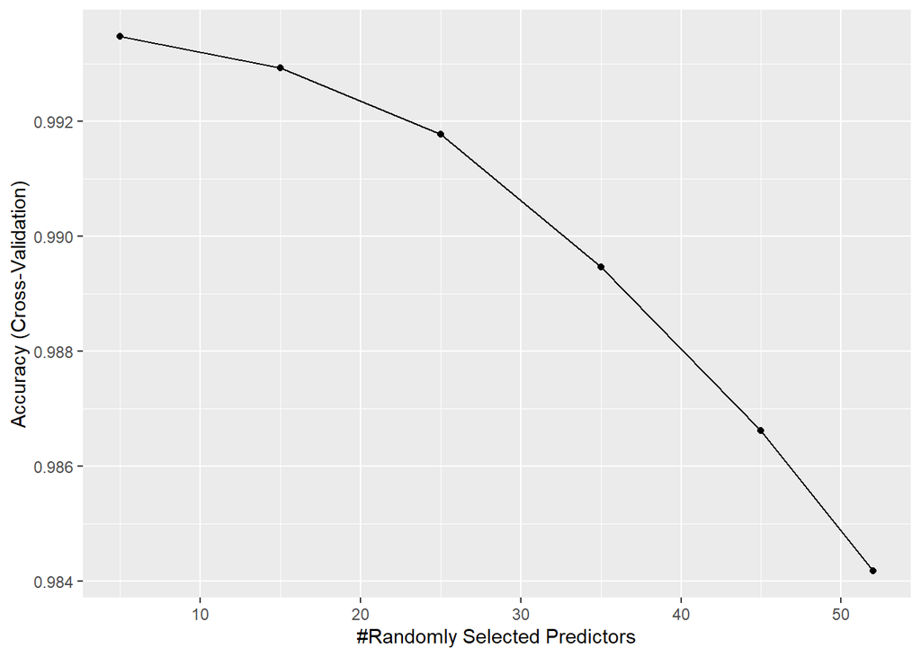

```r
ggplot(fit_rf_2)
```

With k = 5 fold, the estimated out-of-sample accuracy for mtry = 5 is 0.9934775.

And information on the final model:

```r
fit_rf_2$finalModel
```

```
##
## Call:
##  randomForest(x = x, y = y, mtry = param$mtry)
##                Type of random forest: classification
##                      Number of trees: 500
## No. of variables tried at each split: 5
##
##         OOB estimate of  error rate: 0.43%
## Confusion matrix:
##      A    B    C    D    E  class.error
## A 4181    3    0    0    1 0.0009557945
## B   12 2832    4    0    0 0.0056179775
## C    0   14 2552    1    0 0.0058433970
## D    0    0   22 2389    1 0.0095356551
## E    0    0    0    5 2701 0.0018477458
```

Now we apply the model to the testing set to assess performance.

```r
# Using predict() on testing set
pred_rf2_test <- predict(fit_rf_2, newdata = testing)

# Confusion Matrix to assess
confusionMatrix(testing$classe, pred_rf2_test)
```

```
## Confusion Matrix and Statistics
##
##           Reference
## Prediction    A    B    C    D    E
##          A 1395    0    0    0    0
##          B    3  944    2    0    0
##          C    0    3  852    0    0
##          D    0    0   19  785    0
##          E    0    0    0    3  898
##
## Overall Statistics
##
##                Accuracy : 0.9939
##                  95% CI : (0.9913, 0.9959)
##     No Information Rate : 0.2851
##     P-Value [Acc > NIR] : < 2.2e-16
##
##                   Kappa : 0.9923
##
##  Mcnemar's Test P-Value : NA
##
## Statistics by Class:
##
##                      Class: A Class: B Class: C Class: D Class: E
## Sensitivity            0.9979   0.9968   0.9759   0.9962   1.0000
## Specificity            1.0000   0.9987   0.9993   0.9954   0.9993
## Pos Pred Value         1.0000   0.9947   0.9965   0.9764   0.9967
## Neg Pred Value         0.9991   0.9992   0.9948   0.9993   1.0000
## Prevalence             0.2851   0.1931   0.1780   0.1607   0.1831
## Detection Rate         0.2845   0.1925   0.1737   0.1601   0.1831
## Detection Prevalence   0.2845   0.1935   0.1743   0.1639   0.1837
## Balanced Accuracy      0.9989   0.9978   0.9876   0.9958   0.9996
```

The resulting accuracy rate is 0.9939, which is very close to accuracy on training set.

## Predicting Quiz Cases

Now to apply the method to the quiz cases.

We will apply the same transformation and feature selection steps as we did in the training process.

```r
pml_test <- read.csv(file.path(getwd(), "data", "pml-testing.csv"))

# Same for testing data
pml_test <- pml_test %>%
  # Remove meta data
  select(-c(1:7)) %>%
  mutate(
    # transform data to numeric
    across(roll_belt:magnet_forearm_z, ~ as.numeric(.x))
    ) %>%
  # Select non-NA features
  select(problem_id, one_of(name_vec))
```

Using the quiz data set, apply the random forest model to get prediction for each problem ID case.

```r
# predict on pml_test
quiz_df <- data.frame(
  problem_id = pml_test$problem_id,
  pred_classe = predict(fit_rf_2, newdata = pml_test)
)

quiz_df
```

```
##    problem_id pred_classe
## 1           1           B
## 2           2           A
## 3           3           B
## 4           4           A
## 5           5           A
## 6           6           E
## 7           7           D
## 8           8           B
## 9           9           A
## 10         10           A
## 11         11           B
## 12         12           C
## 13         13           B
## 14         14           A
## 15         15           E
## 16         16           E
## 17         17           A
## 18         18           B
## 19         19           B
## 20         20           B
```